# Demand Analysis and Consumer Welfare

Lecture 2

Div Bhagia

# Utility Maximization (contd.)

## Utility Maximization

Consumer’s problem:
$$\max_{x,y} U(x,y) \quad \text{subject to} \quad p_x x + p_y y = I$$

Set up the Lagrangian:
$$L = U(x,y) + \lambda(I - p_x x - p_y y)$$

First-order conditions → demand functions:
$$x^*(p_x, p_y, I) \quad \quad y^*(p_x, p_y, I)$$

Note: These are called **Marshallian (uncompensated) demand** functions.

## Indirect Utility Function

**Definition:** Maximum utility as a function of prices and income

$$V(p_x, p_y, I) = \max_{x,y} U(x,y) \text{ s.t. } p_x x + p_y y = I$$

Or equivalently:
$$V(p_x, p_y, I) = U(x^*(p_x, p_y, I), y^*(p_x, p_y, I))$$

**Properties:**

1. Increasing in $I$: $\frac{\partial V}{\partial I} > 0$
2. Decreasing in prices: $\frac{\partial V}{\partial p_i} \leq 0$
3. Homogeneous of degree zero: $V(tp_x, tp_y, tI) = V(p_x, p_y, I)$

## Application: Gasoline Tax

- Indirect utility as a tool for **welfare analysis** of price/income changes
- **Example**: Government raises gas tax by $0.50/gallon. To compensate, gives everyone $200 cash transfer.
  - To answer if people are better or worse off, compare indirect utility before and after policy.
    - Before: $V(p_{\text{gas}}, p_{\text{other}}, I)$
    - After: $V(p_{\text{gas}} + 0.50, p_{\text{other}}, I + 200)$

**Question**: Would it be better if we could measure welfare in dollars rather than abstract “*utils*”?

# Expenditure Minimization

## The Dual Problem

*Two ways to think about consumer choice.*

**I. Utility Maximization:** Given prices and income, maximize utility

$$\max_{x,y} \ U(x,y) \quad \text{s.t.} \quad p_x x + p_y y = I$$

$\rightarrow$ **Marshallian (uncompensated) demand** and **Indirect Utility Function**.

**II. Expenditure Minimization:** Given prices and a utility target, minimize expenditure

$$\min_{x,y} \ p_x x + p_y y \quad \text{s.t.} \quad U(x,y) = \bar{U}$$

$\rightarrow$ **Hicksian (compensated) demand** and **Expenditure Function**.

## Visualizing Duality

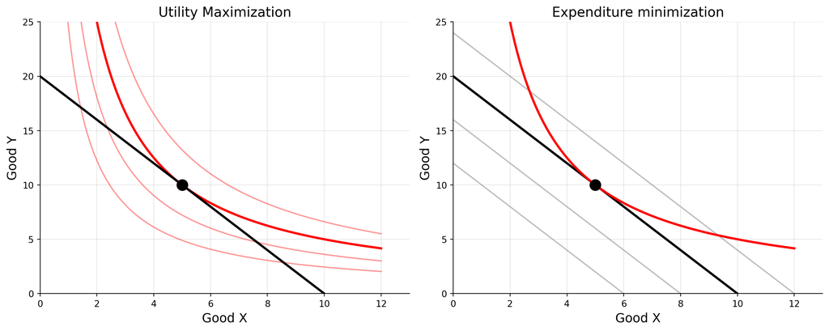

## Expenditure Minimization

Consumer’s problem:
$$\min_{x,y} p_x x + p_y y \quad \text{subject to} \quad U(x, y) = \bar{U}$$

Set up the Lagrangian:
$$L = p_x x + p_y y + \mu(\bar{U}-U(x, y))$$

FOCs give us **Hicksian (compensated) demand functions**:
$$x^h(p_x, p_y, \bar{U}) \quad \quad y^h(p_x, p_y, \bar{U})$$

## Expenditure Function

**Definition:** Minimum expenditure needed to reach $\bar{U}$ at prices $(p_x, p_y)$

$$E(p_x, p_y, \bar{U}) = \min_{x,y} \ p_x x + p_y y \text{ s.t. } U(x,y) = \bar{U}$$

Or equivalently:
$$E(p_x, p_y, \bar{U}) = p_x x^h + p_y y^h$$

**Properties:**

1. Increasing in $\bar{U}$: $\frac{\partial E}{\partial \bar{U}} > 0$
2. Increasing in prices: $\frac{\partial E}{\partial p_i} \geq 0$
3. Homogeneous of degree 1 in prices: $E(tp_x, tp_y, \bar{U}) = t \cdot E(p_x, p_y, \bar{U})$
4. Concave in prices

## Duality: Inverse Relationship

**The indirect utility and expenditure functions are inverses.**

$$V(p_x, p_y, E(p_x, p_y, \bar{U})) = \bar{U}$$

$$E(p_x, p_y, V(p_x, p_y, I)) = I$$

**Practical implications:**

- Can work with whichever function is more convenient
- Welfare analysis: easier to use expenditure function
- Demand analysis: easier to use indirect utility

## Gasoline Tax Revisited

**Example**: Government raises gas tax by $0.50/gallon.

How much will the consumer need to be compensated to reach their original utility level $\bar{U}$?

$$E(p_{\text{gas}} + 0.50, p_{\text{other}}, \bar{U}) - E(p_{\text{gas}}, p_{\text{other}}, \bar{U})$$

Now we have a way of measuring how much worse off the consumer is in **dollar terms**.

# Demand Functions

## Two Types of Demand

**Marshallian (uncompensated) demand:** $x(p_x, p_y, I)$

- From utility maximization
- Holds income fixed as prices change
- Reflects both substitution and income effects

**Hicksian (compensated) demand:** $x^h(p_x, p_y, \bar{U})$

- From expenditure minimization
- *Compensates* the consumer for price changes to keep utility constant
- Reflects only substitution effects
- Sometimes written as $x^c$ for “compensated”

## Relationship Between Two Demands

At optimal consumption, the two demand functions give the same quantity:

$$x(p_x, p_y, I) = x^h(p_x, p_y, V(p_x, p_y, I))$$

where $V(p_x, p_y, I)$ is the maximum utility achieved at income $I$.

**In other words:**

- Start with $(p_x, p_y, I)$
- Marshallian demand: $x^* = x(p_x, p_y, I)$
- Maximum utility: $\bar{U} = V(p_x, p_y, I)$
- Hicksian demand at this utility: $x^h(p_x, p_y, \bar{U}) = x^*$

## Graphical: Marshallian Demand

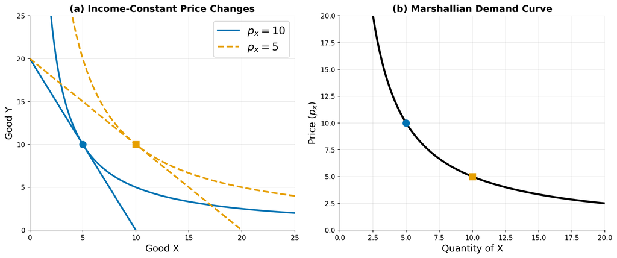

## Decomposing Price Effects

When $p_x$ changes, quantity demanded changes for two reasons:

1. **Substitution effect:** Relative prices change → reallocate consumption
2. **Income effect:** Real purchasing power changes → change consumption

Hicksian demand isolates the substitution effect by holding utility constant.

## Graphical: Hicksian Demand

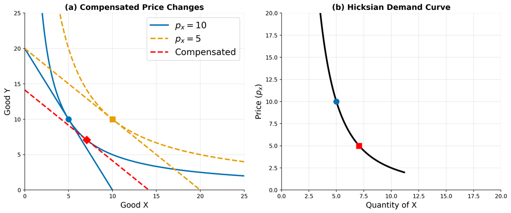

## The Slutsky Equation

$$\underbrace{\frac{\partial x}{\partial p_x}}_{\text{Total effect}} = \underbrace{\frac{\partial x^h}{\partial p_x}}_{\text{Substitution effect (SE)}} - \underbrace{x \cdot \frac{\partial x}{\partial I}}_{\text{Income effect (IE)}}$$

**Substitution effect:**

- Always negative (or zero)
- Pure effect of relative price change
- Movement along indifference curve

**Income effect:**

- Sign depends on whether good is normal or inferior
- Effect of change in real purchasing power
- Movement to different indifference curve

## Three Cases

$$\underbrace{\frac{\partial x}{\partial p_x}}_{TE} = \underbrace{\frac{\partial x^h}{\partial p_x}}_{SE \leq 0} - \underbrace{x \cdot \frac{\partial x}{\partial I}}_{IE}$$

### 1. Normal Good

- $\partial x/\partial I > 0$ (buy more as income rises)
- TE: Strongly negative

### 2. Inferior Good

- $\partial x/\partial I < 0$ (buy less as income rises)
- |IE| < |SE| → TE: Negative (but smaller than normal good)

## Three Cases (Contd.)

$$\underbrace{\frac{\partial x}{\partial p_x}}_{TE} = \underbrace{\frac{\partial x^h}{\partial p_x}}_{SE \leq 0} - \underbrace{x \cdot \frac{\partial x}{\partial I}}_{IE}$$

### 3. Giffen Good

- $\partial x/\partial I < 0$ (inferior good)
- |IE| > |SE| → TE: *Positive* (buy less when price falls)

## Demand Elasticities

**Own-price elasticity (Marshallian):**
$$\varepsilon_{x,p_x} = \frac{\partial x}{\partial p_x} \cdot \frac{p_x}{x}$$

**Income elasticity:**
$$\varepsilon_{x,I} = \frac{\partial x}{\partial I} \cdot \frac{I}{x}$$

**Cross-price elasticity:**
$$\varepsilon_{x,p_y} = \frac{\partial x}{\partial p_y} \cdot \frac{p_y}{x}$$

## Compensated Elasticities

**Compensated own-price elasticity:**
$$\varepsilon_{x,p_x}^c = \frac{\partial x^h}{\partial p_x} \cdot \frac{p_x}{x^h}$$

**Compensated cross-price elasticity:**
$$\varepsilon_{x,p_y}^c = \frac{\partial x^h}{\partial p_y} \cdot \frac{p_y}{x^h}$$

- $\varepsilon_{x,p_x}^c \leq 0$ always (substitution effect)
- $\varepsilon_{x,p_x}^c$ is less negative than $\varepsilon_{x,p_x}$ for normal goods
- Compensated elasticities are symmetric: $\varepsilon_{x,p_y}^c \cdot s_x = \varepsilon_{y,p_x}^c \cdot s_y$

## The Slutsky Equation in Elasticities

Dividing by $x$ and multiplying by $p_x$:

$$\boxed{\varepsilon_{x,p_x} = \varepsilon_{x,p_x}^c - s_x \cdot \varepsilon_{x,I}}$$

where:

- $\varepsilon_{x,p_x}$ = Marshallian price elasticity
- $\varepsilon_{x,p_x}^c$ = compensated price elasticity
- $s_x = \frac{p_x x}{I}$ = budget share of good x
- $\varepsilon_{x,I}$ = income elasticity

**Interpretation:** Total elasticity = substitution elasticity - budget share × income elasticity

# Substitutes and Complements

## Gross (Marshallian) Substitutes and Complements

- Two goods $x$ and $y$ are **gross substitutes** if an increase in the price of $y$ leads to an increase in the demand for $x$:
  $$\frac{\partial x}{\partial p_y} > 0$$
- They are **gross complements** if an increase in the price of $y$ leads to a decrease in the demand for $x$:
  $$\frac{\partial x}{\partial p_y} < 0$$

## Net (Hicksian) Substitutes and Complements

- Two goods $x$ and $y$ are **net substitutes** if an increase in the price of $y$ leads to an increase in the compensated demand for $x$:
  $$\frac{\partial x^h}{\partial p_y} > 0$$
- They are **net complements** if an increase in the price of $y$ leads to a decrease in the compensated demand for $x$:
  $$\frac{\partial x^h}{\partial p_y} < 0$$

# Welfare

## Measuring Welfare Changes

**Question:** How much is a consumer hurt by a price increase?

**Three approaches:**

1. **Compensating Variation (CV):** Money needed to restore original utility after price change
2. **Equivalent Variation (EV):** Money equivalent to price change (willingness to pay to avoid it)
3. **Consumer Surplus (CS):** Area under demand curve

All three approximate welfare changes, but differ in treatment of income effects.

## Compensating Variation

**Definition:** Income needed to compensate for price increase to maintain original utility

For price increase from $p_0$ to $p_1$:

$$CV = E(p_1, p_y, U_0) - E(p_0, p_y, U_0)$$

where $U_0$ is utility before the price change.

**Graphically:** Area under Hicksian demand curve
$$CV = \int_{p_0}^{p_1} x^h(p, p_y, U_0) \, dp$$

## Equivalent Variation

**Definition:** Income change equivalent to price change in terms of utility

For price increase from $p_0$ to $p_1$:
$$EV = E(p_1, p_y, U_1) - E(p_0, p_y, U_1)$$

where $U_1$ is utility after the price change.

***Graphically:** Area under Hicksian demand curve
$$EV = \int_{p_0}^{p_1} x^h(p, p_y, U_1) \, dp$$

## (Change in) Consumer Surplus

**Definition:** Area under Marshallian demand curve between two prices
$$\Delta CS = \int_{p_0}^{p_1} x(p, p_y, I) \, dp$$

- **Advantage:** Easy to estimate from market data
- **Disadvantage:** Only an approximation of welfare change